# Global CO₂ Emissions: Does GDP Predict Emissions and Does Carbon Tax Help?

Isuri

2026-04-07

```r
library(tidyverse)
library(ggplot2)
library(ggrepel)
library(broom)
library(knitr)
library(kableExtra)
```

# 1. Introduction

This case study investigates two related research questions about global CO₂ emissions:

> **Q1:** Does GDP per capita predict CO₂ emissions per capita across countries?

> **Q2:** Does having a carbon tax affect CO₂ emissions in top emitting countries?

Understanding the relationship between economic development, carbon pricing policy, and emissions is critical for designing effective climate policy. A naive analysis might suggest carbon tax increases emissions: this study demonstrates why controlling for confounding variables matters.

## 1.1 Data Sources

| Dataset | Source | Coverage |
| --- | --- | --- |
| CO₂ & Greenhouse Gas Emissions | Our World in Data | 164 countries, 2000–2024 |
| Carbon Pricing Instrument Coverage | World Bank | 164 countries, 1989–2024 |

# 2. Data Loading & Cleaning

## 2.1 Load raw data

```r
co2EmissionData <- read_csv("data/raw/co2-emission.csv",
                             show_col_types = FALSE)
carbonTaxData   <- read_csv("data/raw/carbon-tax-data.csv",
                             show_col_types = FALSE)

cat("CO2 dataset:", nrow(co2EmissionData), "rows x",
    ncol(co2EmissionData), "columns\n")
```

```
## CO2 dataset: 50411 rows x 79 columns
```

```r
cat("Carbon tax dataset:", nrow(carbonTaxData), "rows x",
    ncol(carbonTaxData), "columns\n")
```

```
## Carbon tax dataset: 7236 rows x 4 columns
```

## 2.2 Clean carbon tax data

```r
carbonTaxData <- carbonTaxData %>%
  rename(
    country        = Entity,
    iso_code       = Code,
    year           = Year,
    has_carbon_tax = `Covered by tax instrument in at least one sector`
  ) %>%
  mutate(
    carbon_tax = ifelse(has_carbon_tax == "No carbon tax",
                        FALSE, TRUE)
  ) %>%
  select(country, iso_code, year, carbon_tax) %>%
  filter(year >= 2000 & year <= 2024)

cat("Unique carbon_tax values:",
    paste(unique(carbonTaxData$carbon_tax), collapse = ", "), "\n")
```

```
## Unique carbon_tax values: FALSE, TRUE
```

## 2.3 Clean CO₂ data

```r
co2EmissionData <- co2EmissionData %>%
  filter(!is.na(iso_code),
         year >= 2000 & year <= 2024)

co2EmissionDataCleaned <- co2EmissionData %>%
  select(country, iso_code, year,
         gdp, population, co2,
         co2_per_capita, share_global_co2,
         primary_energy_consumption)

co2EmissionDataCleaned <- co2EmissionDataCleaned %>%
  arrange(country, year) %>%
  group_by(country) %>%
  mutate(
    gdp = ifelse(is.na(gdp),
                 mean(gdp, na.rm = TRUE), gdp),
    primary_energy_consumption = ifelse(
      is.na(primary_energy_consumption),
      mean(primary_energy_consumption, na.rm = TRUE),
      primary_energy_consumption)
  ) %>%
  ungroup()

no_gdp_countries <- co2EmissionDataCleaned %>%
  group_by(country) %>%
  summarise(all_na = all(is.na(gdp)), .groups = "drop") %>%
  filter(all_na) %>%
  pull(country)

cat("Countries removed (no GDP data):",
    length(no_gdp_countries), "\n")
```

```
## Countries removed (no GDP data): 54
```

```r
co2EmissionDataCleaned <- co2EmissionDataCleaned %>%
  filter(!country %in% no_gdp_countries) %>%
  mutate(gdp_per_capita = gdp / population)

cat("\nMissing values after cleaning:\n")
```

```
##
## Missing values after cleaning:
```

```r
print(colSums(is.na(co2EmissionDataCleaned)))
```

```
##                    country                   iso_code
##                          0                          0
##                       year                        gdp
##                          0                          0
##                 population                        co2
##                          0                          0
##             co2_per_capita           share_global_co2
##                          0                          0
## primary_energy_consumption             gdp_per_capita
##                          0                          0
```

## 2.4 Join datasets

```r
co2_tax_gdp <- co2EmissionDataCleaned %>%
  inner_join(
    carbonTaxData %>% select(iso_code, year, carbon_tax),
    by = c("iso_code", "year")
  )

cat("Final dataset:", nrow(co2_tax_gdp), "rows\n")
```

```
## Final dataset: 4100 rows
```

```r
cat("Countries:", n_distinct(co2_tax_gdp$country), "\n")
```

```
## Countries: 164
```

```r
cat("Year range:",
    paste(range(co2_tax_gdp$year), collapse = " to "), "\n")
```

```
## Year range: 2000 to 2024
```

# 3. Data Aggregation

```r
country_avg <- co2_tax_gdp %>%
  group_by(country) %>%
  summarise(
    avg_co2_per_capita = mean(co2_per_capita,  na.rm = TRUE),
    avg_gdp_per_capita = mean(gdp_per_capita,  na.rm = TRUE),
    avg_share_global   = mean(share_global_co2, na.rm = TRUE),
    avg_energy         = mean(primary_energy_consumption,
                              na.rm = TRUE),
    has_carbon_tax     = as.logical(max(carbon_tax,
                                        na.rm = TRUE)),
    .groups = "drop"
  ) %>%
  mutate(
    gdp_level = case_when(
      avg_gdp_per_capita > 12000 ~ "High income",
      avg_gdp_per_capita > 3000  ~ "Middle income",
      TRUE                       ~ "Low income"
    ),
    gdp_level = factor(gdp_level,
                       levels = c("Low income",
                                  "Middle income",
                                  "High income"))
  )

top_countries <- co2_tax_gdp %>%
  filter(year >= 2018 & year <= 2024) %>%
  group_by(country) %>%
  summarise(avg_share = mean(share_global_co2, na.rm = TRUE),
            .groups = "drop") %>%
  arrange(desc(avg_share)) %>%
  slice_head(n = 20) %>%
  pull(country)

cat("Dataset dimensions:", nrow(country_avg),
    "countries\n")
```

```
## Dataset dimensions: 164 countries
```

```r
cat("Top 20 emitters identified\n")
```

```
## Top 20 emitters identified
```

# 4. Exploratory Data Analysis

## 4.1 Distribution of CO₂ per capita

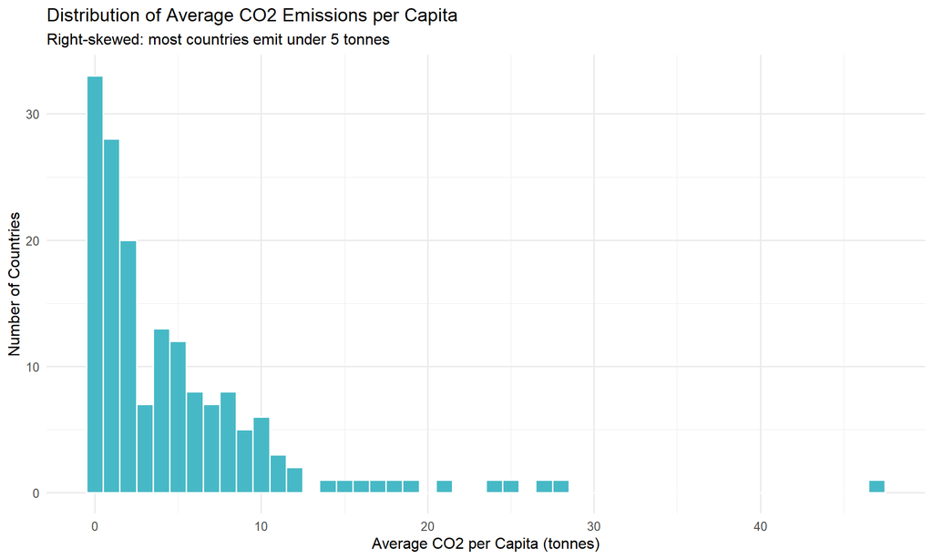

```r
ggplot(country_avg, aes(x = avg_co2_per_capita)) +
  geom_histogram(binwidth = 1, fill = "#47B9C6",
                 color = "white") +
  labs(
    title    = "Distribution of Average CO2 Emissions per Capita",
    subtitle = "Right-skewed: most countries emit under 5 tonnes",
    x = "Average CO2 per Capita (tonnes)",
    y = "Number of Countries"
  ) +
  theme_minimal(base_size = 12)
```

The distribution is strongly right-skewed. Most countries emit fewer than 5 tonnes per capita, while a small number of high-income and fossil-fuel-dependent nations are significant outliers above 15 tonnes.

## 4.2 Top 20 countries by global CO₂ share

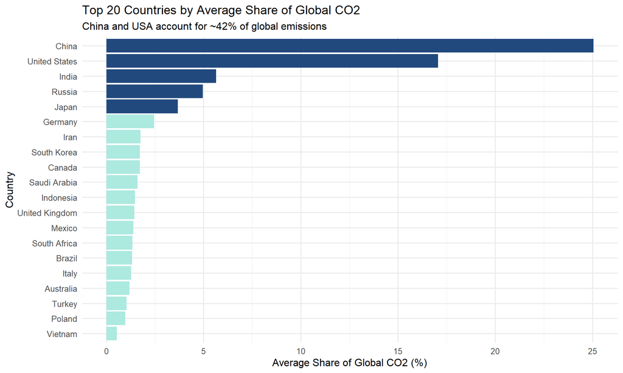

```r
country_avg %>%
  filter(country %in% top_countries) %>%
  arrange(desc(avg_share_global)) %>%
  mutate(top5 = row_number() <= 5) %>%
  ggplot(aes(x = reorder(country, avg_share_global),
             y = avg_share_global, fill = top5)) +
  geom_bar(stat = "identity") +
  coord_flip() +
  scale_fill_manual(
    values = c("TRUE" = "#21497E", "FALSE" = "#ACE9DF"),
    guide  = "none"
  ) +
  labs(
    title    = "Top 20 Countries by Average Share of Global CO2",
    subtitle = "China and USA account for ~42% of global emissions",
    x = "Country",
    y = "Average Share of Global CO2 (%)"
  ) +
  theme_minimal(base_size = 12)
```

China (25%) and the United States (17%) dominate global emissions. The top 5 emitters together account for over 55% of global CO₂.

## 4.3 Carbon tax adoption

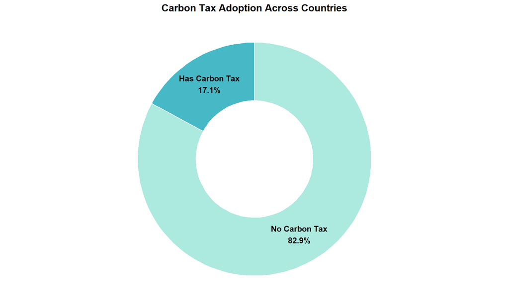

```r
carbon_tax_dist <- country_avg %>%
  group_by(has_carbon_tax) %>%
  summarise(count = n(), .groups = "drop") %>%
  mutate(
    pct   = round(count / sum(count) * 100, 1),
    label = ifelse(has_carbon_tax,
                   "Has Carbon Tax", "No Carbon Tax")
  )

ggplot(carbon_tax_dist,
       aes(x = 2, y = pct, fill = label)) +
  geom_bar(stat = "identity", width = 1,
           color = "white", linewidth = 0.5) +
  coord_polar(theta = "y") +
  xlim(0.5, 2.5) +
  geom_text(aes(label = paste0(label, "\n", pct, "%")),
            position = position_stack(vjust = 0.5),
            fontface = "bold", size = 4) +
  scale_fill_manual(values = c(
    "Has Carbon Tax" = "#47B9C6",
    "No Carbon Tax"  = "#ACE9DF"
  )) +
  labs(title = "Carbon Tax Adoption Across Countries") +
  theme_void() +
  theme(legend.position = "none",
        plot.title = element_text(hjust = 0.5,
                                  face = "bold",
                                  size = 14))
```

Only **17.1%** of countries have adopted a carbon tax. This limited adoption makes cross-country comparison feasible but means the taxed group is a minority.

## 4.4 GDP per capita vs CO₂ per capita

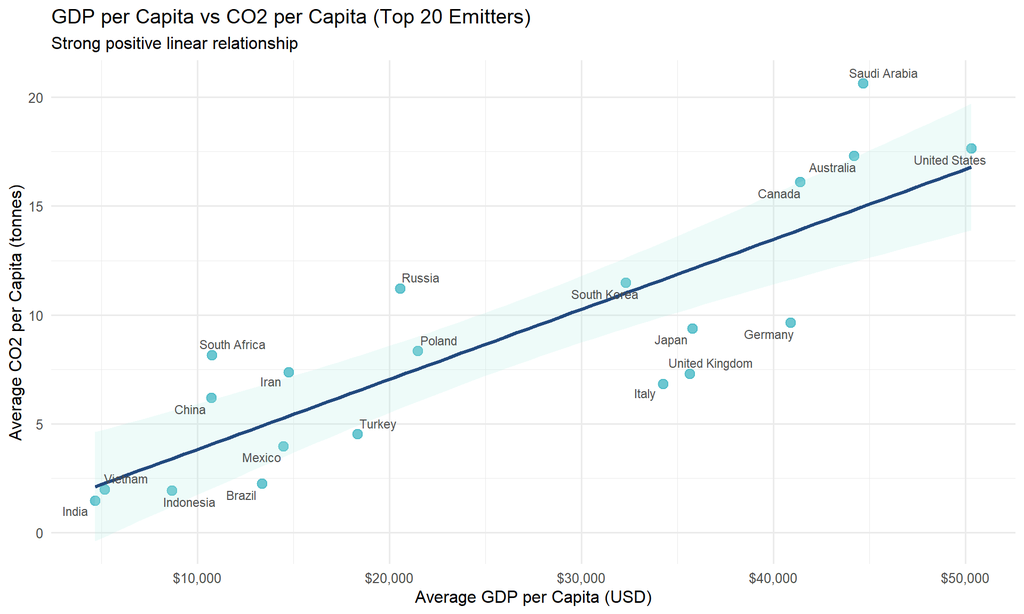

```r
country_avg %>%
  filter(country %in% top_countries) %>%
  ggplot(aes(x = avg_gdp_per_capita,
             y = avg_co2_per_capita)) +
  geom_point(color = "#47B9C6", size = 3, alpha = 0.8) +
  geom_smooth(method = "lm", se = TRUE,
              color = "#21497E", fill = "#ACE9DF",
              alpha = 0.2) +
  geom_text_repel(aes(label = country),
                  size = 3, color = "grey30") +
  scale_x_continuous(labels = scales::dollar_format()) +
  labs(
    title    = "GDP per Capita vs CO2 per Capita (Top 20 Emitters)",
    subtitle = "Strong positive linear relationship",
    x = "Average GDP per Capita (USD)",
    y = "Average CO2 per Capita (tonnes)"
  ) +
  theme_minimal(base_size = 12)
```

A clear positive relationship is visible. Notable exceptions include Saudi Arabia (high emissions relative to GDP) and Germany/UK (lower emissions than GDP would predict, possibly due to carbon pricing and energy efficiency policies).